# Lab5

Bek

2023-09-26

# Tasks

## Task1

```r
getwd()
```

```
## [1] "C:/Users/askub/OneDrive - University of Oklahoma/MATH4753/Lab5/Applied-Statistics-with-R-Lab-5"
```

## Task2

### simulate a binomial experiment where n=10,p=0.7, and Y=number of successes. For 100, 200, 500, 1000, 10000 iterations

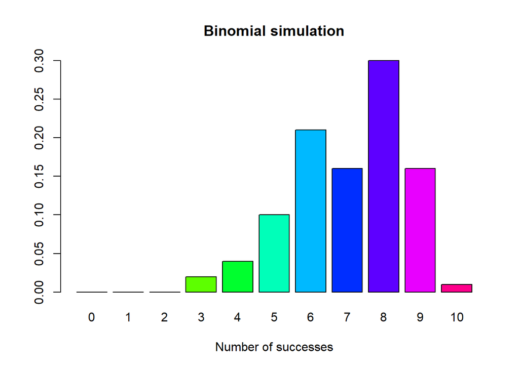

```
##
##    0    1    2    3    4    5    6    7    8    9   10
## 0.00 0.00 0.00 0.02 0.04 0.10 0.21 0.16 0.30 0.16 0.01
```

```r
library(MATH4753LAB5)

mybin(iter = 100, n=10, p = 0.7)
```

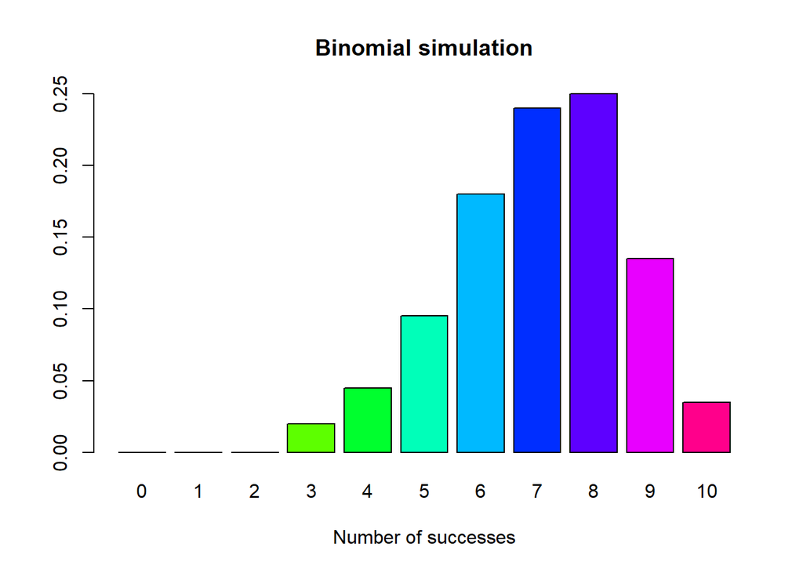

```
##
##     0     1     2     3     4     5     6     7     8     9    10
## 0.000 0.000 0.000 0.020 0.045 0.095 0.180 0.240 0.250 0.135 0.035
```

```r
mybin(iter = 200, n=10, p = 0.7)
```

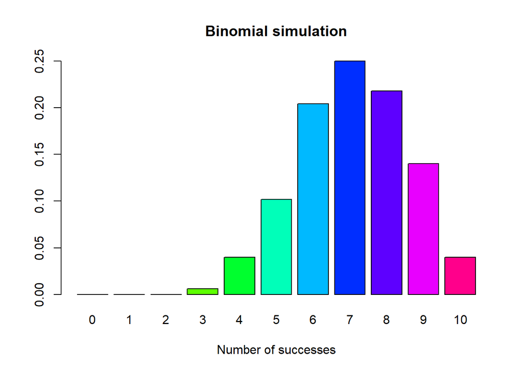

```
##
##     0     1     2     3     4     5     6     7     8     9    10
## 0.000 0.000 0.000 0.006 0.040 0.102 0.204 0.250 0.218 0.140 0.040
```

```r
mybin(iter = 500, n=10, p = 0.7)
```

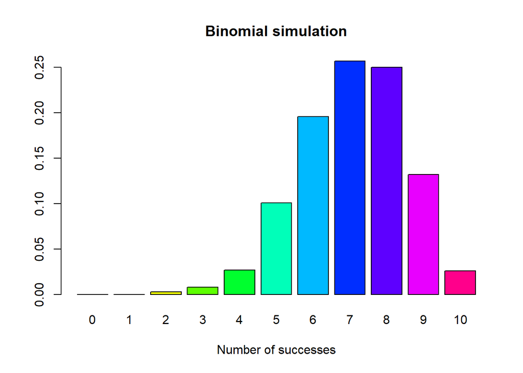

```
##
##     0     1     2     3     4     5     6     7     8     9    10
## 0.000 0.000 0.003 0.008 0.027 0.101 0.196 0.257 0.250 0.132 0.026
```

```r
mybin(iter = 1000, n=10, p = 0.7)
```

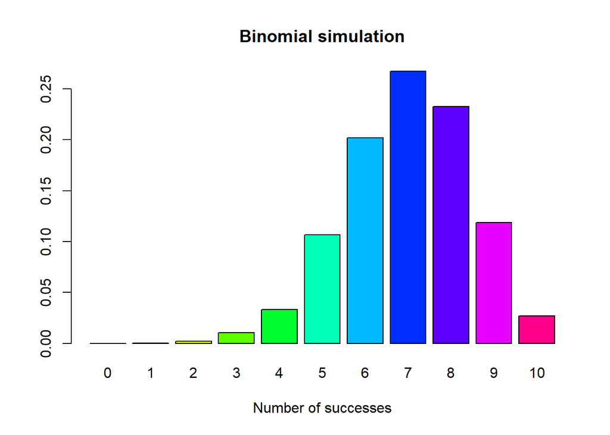

```
##
##      0      1      2      3      4      5      6      7      8      9     10
## 0.0000 0.0003 0.0020 0.0104 0.0334 0.1066 0.2019 0.2673 0.2326 0.1186 0.0269
```

```r
mybin(iter = 10000, n=10, p = 0.7)
```

### For the last simulation (10,000 iterations) copy and paste the table that is produced from the function.

[output not shown]

```r
dbinom(0, 10, 0.7)
```

```
## [1] 5.9049e-06
```

```r
dbinom(1, 10, 0.7)
```

```
## [1] 0.000137781
```

```r
dbinom(2, 10, 0.7)
```

```
## [1] 0.001446701
```

```r
dbinom(3, 10, 0.7)
```

```
## [1] 0.009001692
```

```r
dbinom(4, 10, 0.7)
```

```
## [1] 0.03675691
```

```r
dbinom(5, 10, 0.7)
```

```
## [1] 0.1029193
```

```r
dbinom(6, 10, 0.7)
```

```
## [1] 0.2001209
```

```r
dbinom(7, 10, 0.7)
```

```
## [1] 0.2668279
```

```r
dbinom(9, 10, 0.7)
```

```
## [1] 0.1210608
```

```r
dbinom(9, 10, 0.7)
```

```
## [1] 0.1210608
```

```r
dbinom(10, 10, 0.7)
```

```
## [1] 0.02824752
```

The answers using dbinom differs from the simulations, probably because dbinom gives expected answers. Therefore, the larger the iteration, the more the simulation values get closer to expected values.

## Task3

### Suppose that there is a bag of 20 marbles, 12 white (“1”) and 8 black “0”

### Use the function myhyper(), on CANVAS, assume Y = number of whites, remember sampling is without replacement, n=5.

### Use this code to make barplots of Y for the following number of iterations 100, 200, 500, 1000, 10000

```r
marbles = c(1, 1, 1, 1, 1, 1, 1, 1, 1, 1, 1, 1, 0, 0, 0, 0, 0, 0, 0, 0)
sample(marbles, 5, replace = FALSE)
```

```
## [1] 0 0 1 1 0
```

```r
sample(marbles, 5, replace = TRUE)
```

```
## [1] 1 1 1 1 0
```

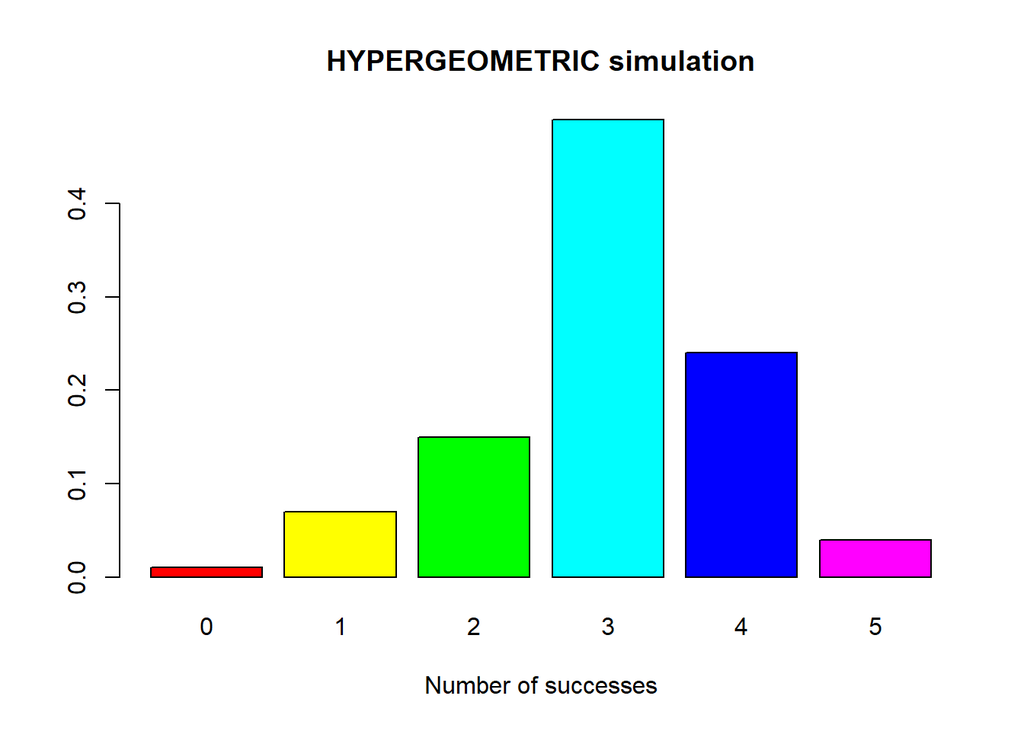

```
##
##    0    1    2    3    4    5
## 0.01 0.07 0.15 0.49 0.24 0.04
```

```r
myhyper(iter=100, N = 20, r = 12, n =5)
```

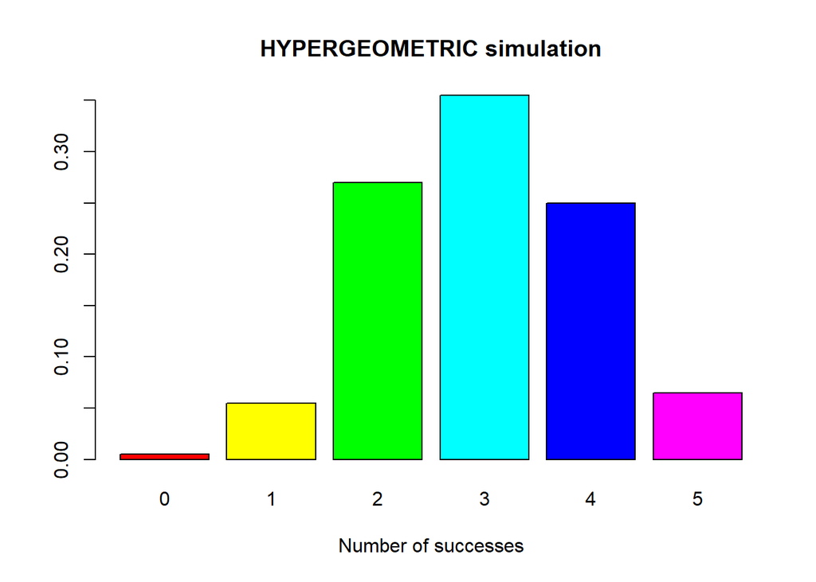

```
##
##     0     1     2     3     4     5
## 0.005 0.055 0.270 0.355 0.250 0.065
```

```r
myhyper(iter=200, N = 20, r = 12, n =5)
```

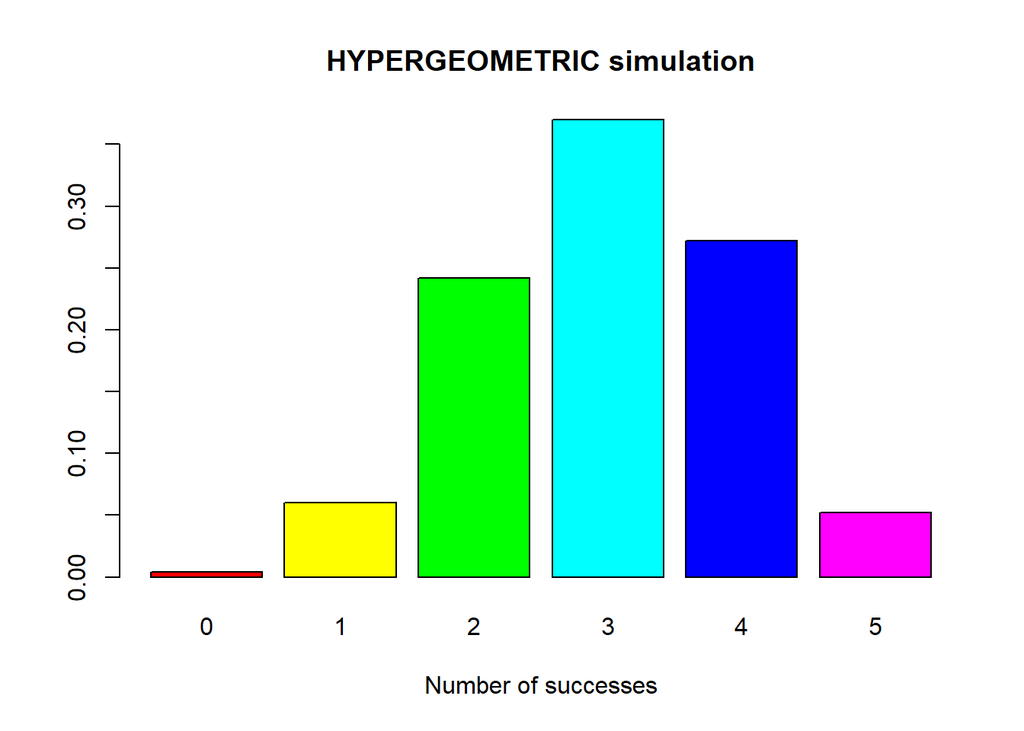

```
##
##     0     1     2     3     4     5
## 0.004 0.060 0.242 0.370 0.272 0.052
```

```r
myhyper(iter=500, N = 20, r = 12, n =5)
```

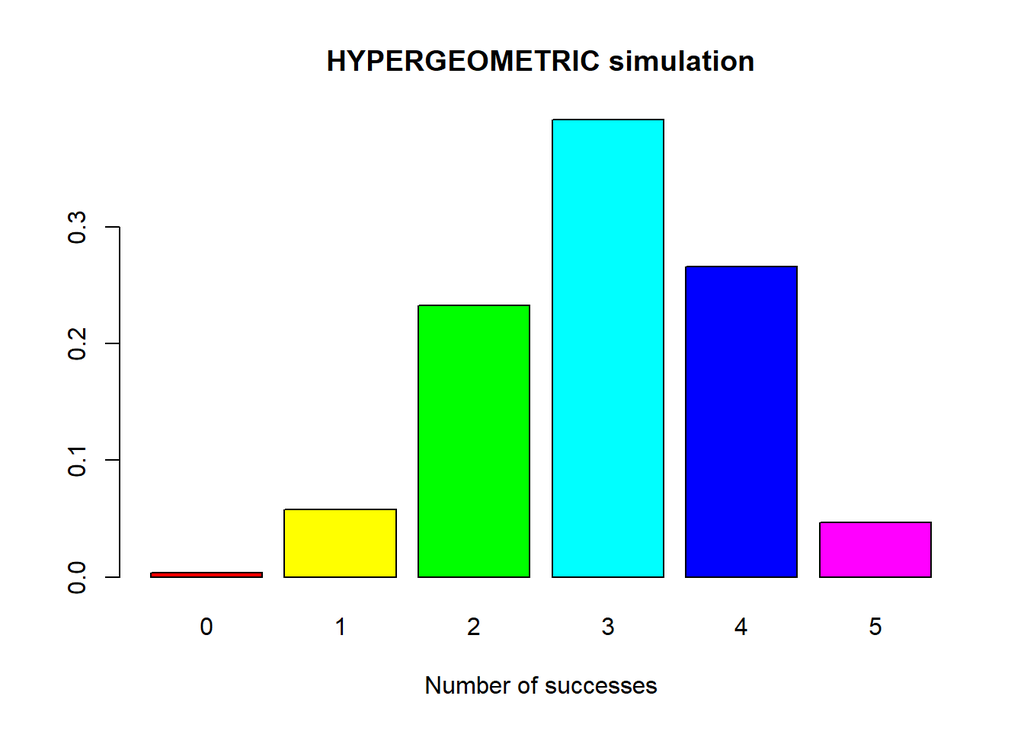

```
##
##     0     1     2     3     4     5
## 0.004 0.058 0.233 0.392 0.266 0.047
```

```r
myhyper(iter=1000, N = 20, r = 12, n =5)
```

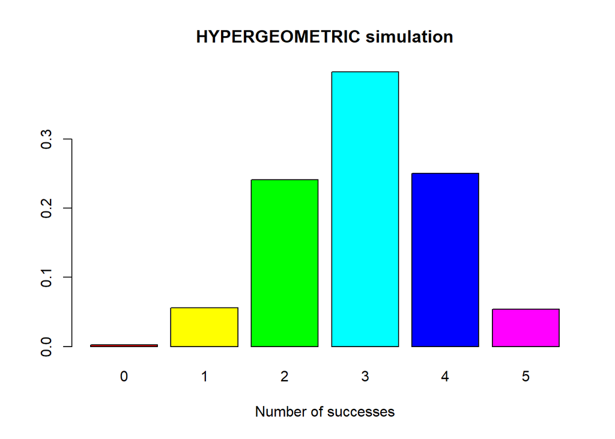

```
##
##      0      1      2      3      4      5
## 0.0024 0.0557 0.2410 0.3971 0.2500 0.0538
```

```r
myhyper(iter=10000, N = 20, r = 12, n =5)
```

### For the last simulation (10,000 iterations) copy and paste the table that is produced from the function.

[output not shown]

```r
round(dhyper(0:5, m=12, n=8,k=5), 4)
```

```
## [1] 0.0036 0.0542 0.2384 0.3973 0.2554 0.0511
```

dhyper results are very close to myhyper results

## Task4

### In lab5.r there is a function called mysample(). Look at the code and describe what you think it should do – record your response here.

It will probably draw a barplot consisting of multiple samples

### Run the function with the following arguments mysample(n=1000, iter=30,time=1)

mysample(n = 1000, iter = 30, time = 1)

It displays barplots with replacement that display iterations from 1 to 30 that were selected from 1 to 10.

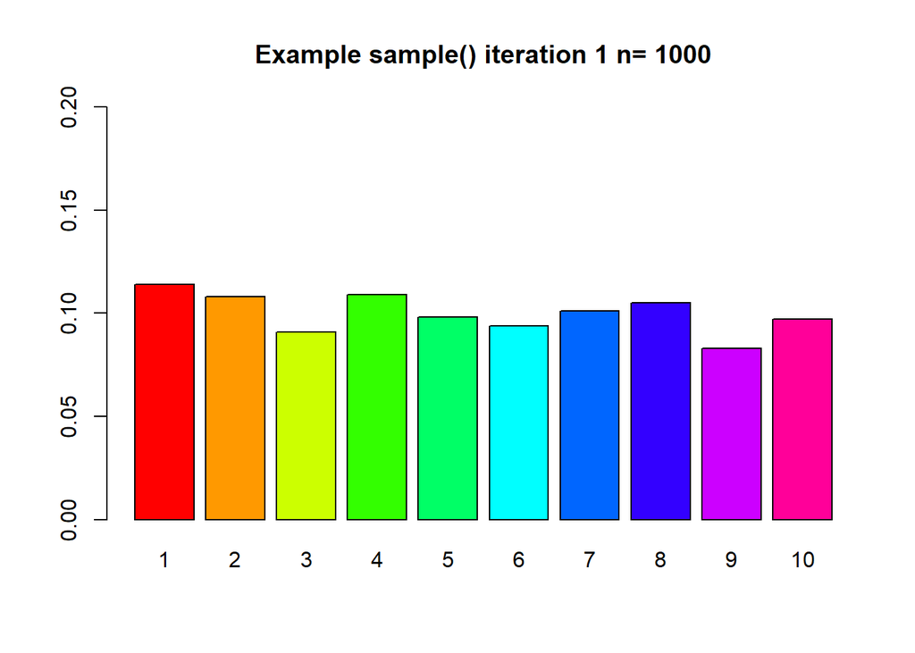

```r
mysample(n = 1000, iter = 1, time = 1)
```

## Task5

```r
choose(8,4)
```

```
## [1] 70
```

```r
1-ppois(4, lambda = 2)
```

```
## [1] 0.05265302
```

### Some more calculations in R

```
P(Y=10),Y~NegBin(p=0.4,r=3) see CANVAS which has a full explanation of this.
P(Y≤8),Y~Bin(n=15,p=0.4)
```

```r
dnbinom(7,3,0.4)
```

```
## [1] 0.06449725
```

```r
mynbin=function(y,r,p){

  choose(y-1,r-1)*p^r*(1-p)^(y-r)
}

mynbin(10,3,0.4)
```

```
## [1] 0.06449725
```

```r
pbinom(8,size = 15,p=0.4)
```

```
## [1] 0.9049526
```

## Task6

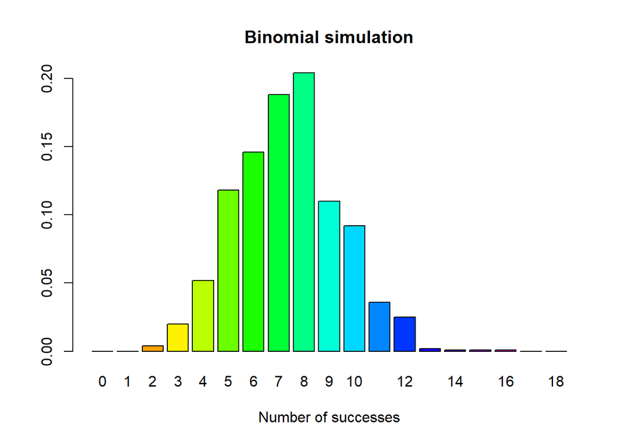

```
##
##     0     1     2     3     4     5     6     7     8     9    10    11    12
## 0.000 0.000 0.004 0.020 0.052 0.118 0.146 0.188 0.204 0.110 0.092 0.036 0.025
##    13    14    15    16    17    18
## 0.002 0.001 0.001 0.001 0.000 0.000
```

```r
MATH4753LAB5::mybin(iter=1000,n=18, p=0.4)
```